# VEGANScreener + metabolomics

Q3: Associations between hPDI and the metabolome in vegans.

**This script explores patterns in the metabolome profiles of vegans, particularly by linking them to the PDI score.**

The script is divided into two parts, based on how the metabolome datasets were integrated (see the preprocessing scripts for details). The first part analyzes the **sPCA dataset**, which is used for multivariate analysis, PCA visualization, PERMANOVA, and the machine-learning models. The second part uses the **concatenated dataset** (LC-MS and NMR combined) for the univariate analysis.

The analysis is composed of the following main parts:

1. Global visualization — the first three components, color-coded by **hPDI**.
2. PERMANOVA — how much of the variation can be explained by various external variables: dist(Metabolome) ~ sex + bmi + age + veganDuration + country***hPDI**
3. Univariate analysis (feature-wise model) — linear modelling of each metabolite against various external variables: Metabolite ~ sex + bmi + age + veganDuration + Country***hPDI**
4. Random forest (RF) classification — the model is trained and validated by bootstrapping with 500 iterations, and used to distinguish between participants in the **1st and 3rd tertiles of hPDI**. Two types of models are trained:
1. a model on the original sPCA dataset
2. a model on the sPCA dataset after regressing out the covariates.

# 1 Import

```r
metadata_df <- read.table(
  file =  "../../data/preprocessed/metadata_preprocessed_v3.tsv",
  header = TRUE)

lcms_df <- read.table(
  file= "../../data/preprocessed/metabolomics/lc_ms_preprocessed_INT_v3.tsv",
  check.names = FALSE)

nmr_df <- read.table(
  file = "../../data/preprocessed/metabolomics/nmr_preprocessed_INT_v3.tsv",
  check.names = FALSE)

spca_integrated_df <-  read.table(
  file = "../../data/preprocessed/metabolomics/spca_integrated_vegans_INT_v3.tsv",
  check.names = FALSE)

pdi_df <- read.table(
  file = "../../data/preprocessed/dietary/pdi/pdi_avg_residuals_scaled_v3.tsv",
  check.names = FALSE,
  header = TRUE) %>%
  dplyr::select(study_id,pdi_avg,hpdi_avg,updi_avg) %>%
  dplyr::mutate(hpdi_avg = hpdi_avg + 30,
               updi_avg = updi_avg + 30)

metadata_df <- merge(metadata_df,pdi_df,by = "study_id",all.x = TRUE)
```

```r
metadata_df <- metadata_df %>% dplyr::filter(!is.na(hpdi_avg))
nmr_df <- nmr_df %>% dplyr::filter(rownames(.) %in% metadata_df$study_id)
lcms_df <- lcms_df %>% dplyr::filter(rownames(.) %in% metadata_df$study_id)
spca_integrated_df <- spca_integrated_df %>% dplyr::filter(rownames(.) %in% metadata_df$study_id)
```

**Scaling** — when metadata columns are used as covariates, they need to be scaled so that each has a mean of 0 and a standard deviation of 1.

```r
metadata_scaled_df <- metadata_df
metadata_scaled_df[,-c(1,3,5,6,8)] <- apply(metadata_df[,-c(1,3,5,6,8)],2,scale)
metadata_scaled_df <- metadata_scaled_df %>%
  mutate(sex=as.factor(sex),
         country=as.factor(country),
         group=as.factor(group),
         diet_supplements=as.factor(diet_supplements))
```

# 2 Descriptive statistics

Summary of participant counts by diet group, country, and sex:

```r
metadata_df %>% dplyr::group_by(country,sex) %>% dplyr::count()
```

```
# A tibble: 10 × 3
# Groups:   country, sex [10]
   country sex       n
   <chr>   <chr> <int>
 1 BE      F        51
 2 BE      M        25
 3 CH      F        23
 4 CH      M        20
 5 CZ      F        34
 6 CZ      M        35
 7 DE      F        49
 8 DE      M        42
 9 ES      F        28
10 ES      M        15
```

Basic plots showing the distribution of selected variables:

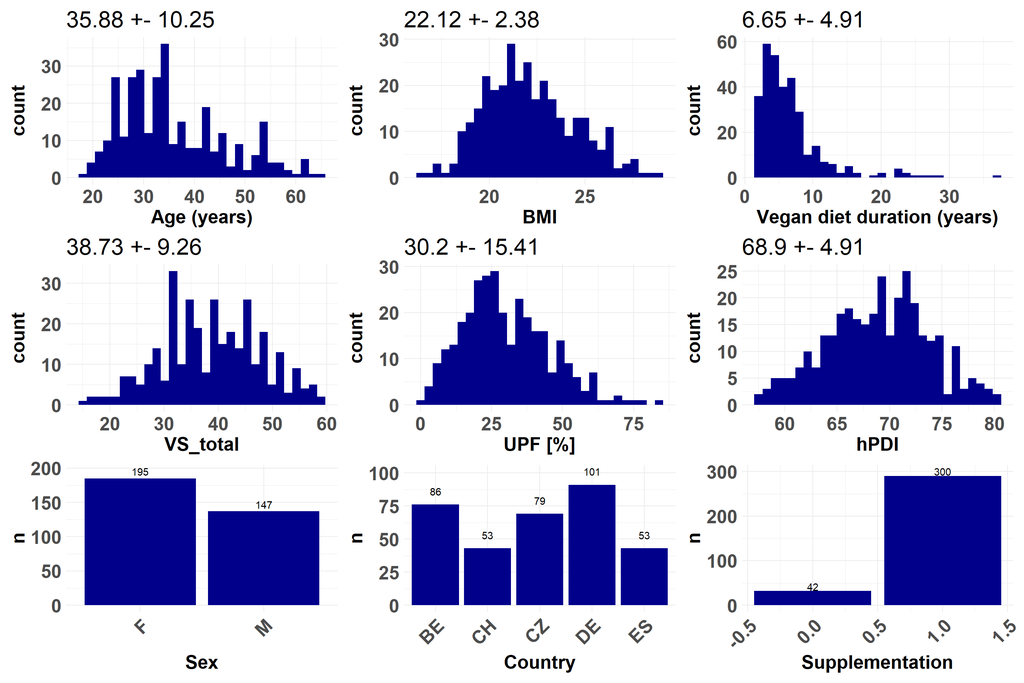

```r
plot_list <- list()
name <- c("Age (years)","BMI","Vegan diet duration (years)","VS_total","UPF [%]",
          "hPDI")
i <- 1
for (col in c("age","bmi","vegan_duration","VS_total","UPF_perc_avg",
              "hpdi_avg")){
  p <- ggplot(metadata_df) +
    geom_histogram(aes(x=!!sym(col)),fill="darkblue") +
    theme_minimal() +
    theme(axis.title = element_text(face="bold",size=20),
          axis.text=element_text(face="bold",size=20),
          title = element_text(face = "plain",size=20)) +
    xlab(name[i]) +
    ggtitle(paste(round(mean(metadata_df[,col],na.rm = TRUE),2),"+-", round(sd(metadata_df[,col],na.rm = TRUE),2)))

  plot_list[[length(plot_list)+1]] <- p
  i <- i + 1

}
i <- 1
name <- c("Sex","Country","Supplementation")
for (col in c("sex","country","diet_supplements")){
  p <- ggplot(metadata_df) +
        theme_minimal() +
     theme(axis.title = element_text(face="bold",size=20),
          axis.text=element_text(face="bold",size=20),
          axis.text.x=element_text(angle = 45,hjust = 1)) +
    stat_count(aes(x=!!sym(col)),fill="darkblue") +
    xlab(name[i]) +
  geom_text(data=metadata_df %>%
              dplyr::group_by(!!sym(col)) %>% dplyr::count() %>%
              dplyr::mutate(n=n+10), aes(x=!!sym(col),y=n,label=n))

  plot_list[[length(plot_list)+1]] <- p

  i <- i+1
}

wrap_plots(plot_list)
```

# 3 SPCA

The sPCA dataset was created by concatenating the LC-MS and NMR datasets and applying the mixOmics::spca() function. See the preprocessing script for details.

mixOmics::spca() performs **sparse Principal Component Analysis (sPCA)**, which works like regular PCA but adds a sparsity constraint so that only a subset of variables contributes to each component. The degree of sparsity is controlled by a penalization term, which makes the components easier to interpret because irrelevant or noisy variables are given loadings of zero.

## 3.1 Visualization

### 3.1.1 PCA

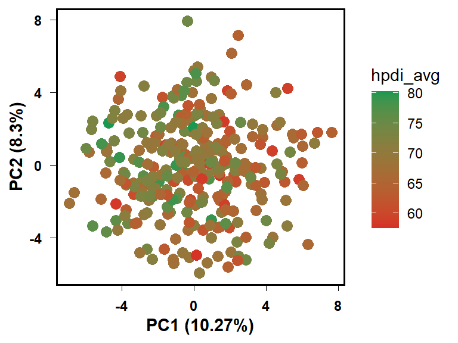

```r
spca_plot_df <- merge(
  spca_integrated_df %>% rownames_to_column("study_id"),
  metadata_df,by="study_id")

p <- pca_plot(spca_integrated_df,
              metadata_df,
              color_col = "hpdi_avg",
              perform_pca = FALSE)

p <- ggtheme(p)

p
```

```r
p_pca <- list()
p_pca[[1]] <- p
```

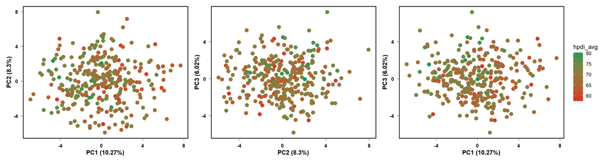

```r
spca_plot_df <- merge(
  spca_integrated_df %>% rownames_to_column("study_id"),
  metadata_df,by="study_id")

p1 <- pca_plot(spca_integrated_df,
              metadata_df,
              color_col = "hpdi_avg",
              perform_pca = FALSE,axis = c("PC1","PC2"))

p1 <- ggtheme(p1)

p2 <- pca_plot(spca_integrated_df,
              metadata_df,
              color_col = "hpdi_avg",
              perform_pca = FALSE,axis = c("PC2","PC3"))

p2 <- ggtheme(p2)

p3 <- pca_plot(spca_integrated_df,
              metadata_df,
              color_col = "hpdi_avg",
              perform_pca = FALSE,axis = c("PC1","PC3"))

p3 <- ggtheme(p3)

p1 + p2 + p3 +
plot_layout(guides = "collect")
```

### 3.1.2 Boxplots

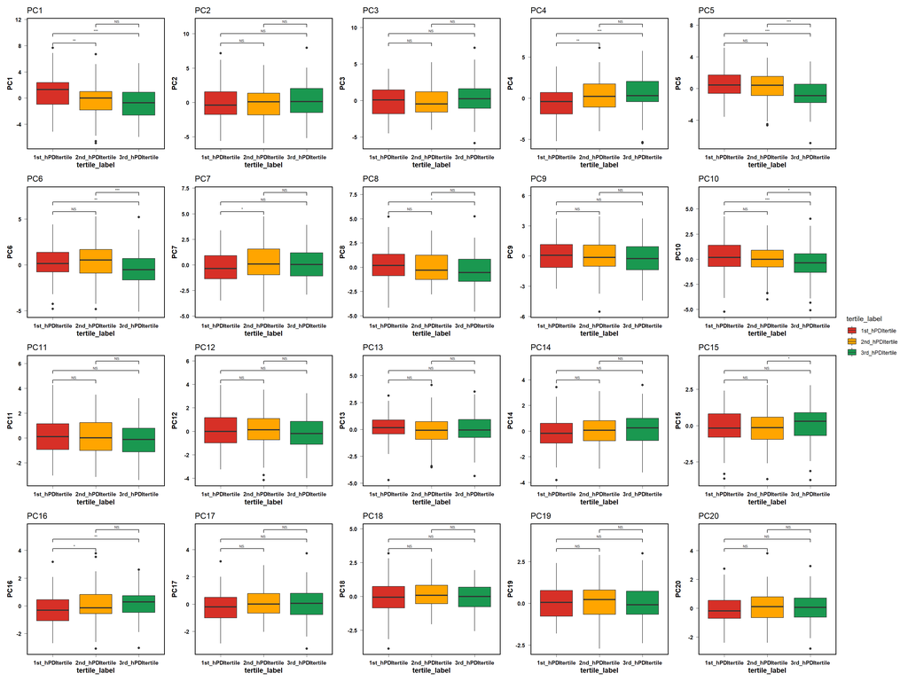

```r
spca_for_uni <- merge(spca_integrated_df %>% rownames_to_column("study_id"),
                      metadata_scaled_df,by="study_id",all = TRUE)

spca_for_uni <- spca_for_uni %>%
  mutate(
    tertile_cut = ntile(hpdi_avg, 3), # assign 1, 2, or 3 (tertile)
    tertile_label = case_when(                          # label tertiles
      tertile_cut == 1 ~ "1st_hPDItertile",
      tertile_cut == 2 ~ "2nd_hPDItertile",
      tertile_cut == 3 ~ "3rd_hPDItertile"
    )
  )

plot_list <- list()
for (col in colnames(spca_integrated_df)){
  p <- ggplot(spca_for_uni,
              aes_string(x = "tertile_label",y = col,fill="tertile_label")) +
    geom_boxplot() +
    ggtitle(col) +
    theme_minimal() +
    scale_fill_manual(values = c("#D73027","orange","#1A9850")) +
    geom_signif(comparisons =
                  combn(as.character(unique(spca_for_uni$tertile_label)),
                        m=2, simplify = FALSE),
                map_signif_level = TRUE, step_increase = 0.1,textsize = 2)

  p <- ggtheme(p)
  plot_list[[length(plot_list) + 1]] <- p
}


a <- wrap_plots(plot_list,guides = "collect")

a
```

### 3.1.3 Heatmap

```r
metadata_df <- metadata_df %>%
  mutate(
    tertile_cut = ntile(hpdi_avg, 3), # assign 1, 2, or 3 (tertile)
    tertile_label = case_when(                          # label tertiles
      tertile_cut == 1 ~ "1st_hPDItertile",
      tertile_cut == 2 ~ "2nd_hPDItertile",
      tertile_cut == 3 ~ "3rd_hPDItertile"
    )
  ) %>%
  dplyr::select(-tertile_cut)
```

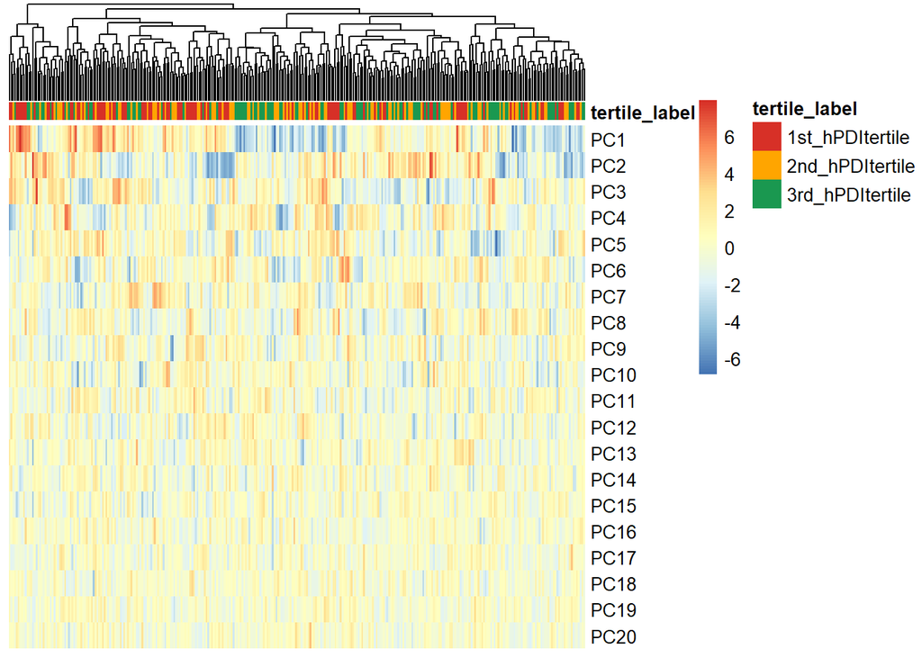

```r
PDI_colors <- c("1st_hPDItertile"="#D73027",
               "2nd_hPDItertile"="orange",
               "3rd_hPDItertile"="#1A9850")

p_df <- spca_integrated_df %>% t()

ann_df <- metadata_df %>% dplyr::select(study_id,tertile_label) %>%
  column_to_rownames("study_id")

ann_colors <- list(
  "tertile_label"=PDI_colors
)
names(ann_colors[["tertile_label"]]) <- names(PDI_colors)

p <- pheatmap(p_df,cluster_rows = FALSE,show_colnames = FALSE,
              annotation_col = ann_df,
              annotation_colors = ann_colors,silent = TRUE)

p
```

**Tertile averages**

```r
metadata_df %>%
  dplyr::select(hpdi_avg, tertile_label) %>%
  group_by(tertile_label) %>%
  summarise(mean_hPDI = mean(hpdi_avg, na.rm = TRUE))
```

```
# A tibble: 3 × 2
  tertile_label   mean_hPDI
  <chr>               <dbl>
1 1st_hPDItertile      63.4
2 2nd_hPDItertile      69.1
3 3rd_hPDItertile      74.3
```

## 3.2 PERMANOVA

The test shows how much of the variation in the metabolome is explained by sex, age, BMI, vegan duration, country, and **hPDI**.

Variables were added sequentially (Type I sums of squares), so each p-value and R² reflects a partial effect after adjusting for the variables above it. The model first accounts for variation due to sex, age, vegan diet duration, BMI, and country of origin. It then accounts for the main effect of PDI, and finally tests whether the effect of PDI varies by country of origin (the interaction term).

```r
# Create Euclidean distance matrix
dist_mat <- vegdist(spca_integrated_df,
                    method = "euclidean")

# Test whether vegan vs omnivore differ in metabolomics
adonis_result <- adonis2(
  dist_mat ~ sex + bmi + age + vegan_duration + country*hpdi_avg,
  data = metadata_scaled_df ,
  permutations = 999,
  by="terms")

print(adonis_result)
```

```
Permutation test for adonis under reduced model
Terms added sequentially (first to last)
Permutation: free
Number of permutations: 999

adonis2(formula = dist_mat ~ sex + bmi + age + vegan_duration + country * hpdi_avg, data = metadata_scaled_df, permutations = 999, by = "terms")
                  Df SumOfSqs      R2       F Pr(>F)
sex                1    981.3 0.05542 21.7350  0.001 ***
bmi                1    145.2 0.00820  3.2153  0.001 ***
age                1    245.6 0.01387  5.4408  0.001 ***
vegan_duration     1     46.6 0.00263  1.0324  0.422
country            4   1745.8 0.09860  9.6671  0.001 ***
hpdi_avg           1    425.9 0.02405  9.4333  0.001 ***
country:hpdi_avg   4    210.6 0.01189  1.1662  0.176
Residual         308  13905.6 0.78533
Total            321  17706.6 1.00000
---
Signif. codes:  0 '***' 0.001 '**' 0.01 '*' 0.05 '.' 0.1 ' ' 1
```

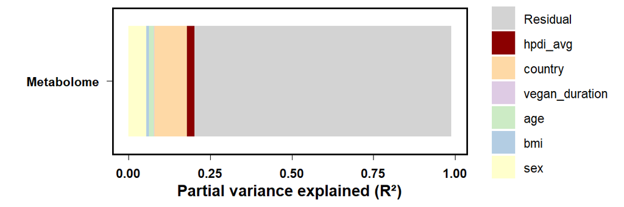

```r
adonis_result <- adonis_result[-c(7,9),] %>% rownames_to_column("Var")
adonis_result$Var <- factor(adonis_result$Var,levels = rev(c("sex","bmi","age", "vegan_duration","country","hpdi_avg", "Residual")))
p <- ggplot(adonis_result, aes(fill=Var, x=R2, y="Metabolome")) +
    geom_bar(position="stack", stat="identity") +
  ylab("") + xlab("Partial variance explained (R²)") +
  scale_fill_manual(values=rev(c("#ffffcc","#b3cde3","#ccebc5",
                                 "#decbe4","#fed9a6","darkred",
                                 "lightgrey")),name = "Covariate")

p <- ggtheme(p)

p
```

```r
p_pca[[2]] <- p
p_pca[[3]] <- adonis_result
```

## 3.3 RF model

### 3.3.1 Original model

```r
sub_metadata_df <- metadata_df %>%
dplyr::filter(
  tertile_label %in% c("1st_hPDItertile","3rd_hPDItertile"))

sub_spca_integrated_df <- spca_integrated_df[as.character(sub_metadata_df$study_id),]
```

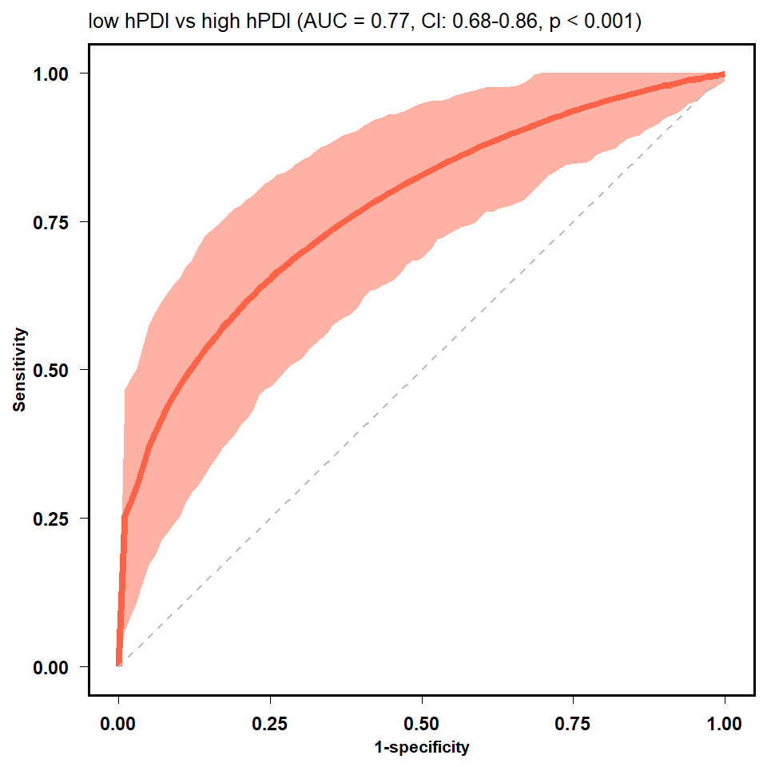

```r
model_name <- "hPDI_tertile_vegan"

prepared_df <- model_preparation(sub_spca_integrated_df,
                                 sub_metadata_df,
                                 predicting_col = "tertile_label")

rf_model <- make_rf_model(data=prepared_df,
                            outcome="Group",
                            N = 500,
                           file = model_name,
                            reuse=TRUE)

roc_c <- roc_curve(model_object = rf_model,
                   group = c("low hPDI","high hPDI"),CI = TRUE)

roc_c <- ggtheme(roc_c) +
  theme(legend.position="none",title = element_text(size=8))

roc_c
```

**Accuracy**

```r
# Find the "best" threshold using Youden's J Index
# This maximizes (Sensitivity + Specificity - 1)
roc_obj <- rf_model$rocobj
best_threshold_data <- coords(roc_obj, "best",
                              ret = "threshold",
                              best.method = "youden")
optimal_threshold <- best_threshold_data$threshold
optimal_threshold
```

```
[1] 0.4715
```

```r
# saving the results
save_rf_details("../results/vegan/RF_models_performance.xlsx",model_name,rf_model)
```

```
[1] "Results saved to ../results/vegan/RF_models_performance.xlsx"
```

### 3.3.2 Adjusted model

```r
# Covariates to adjust for
covars <- c("sex","bmi", "age", "country", "vegan_duration")
integrated_df <- sub_spca_integrated_df
all(rownames(integrated_df) == sub_metadata_df$study_id)
```

```
[1] TRUE
```

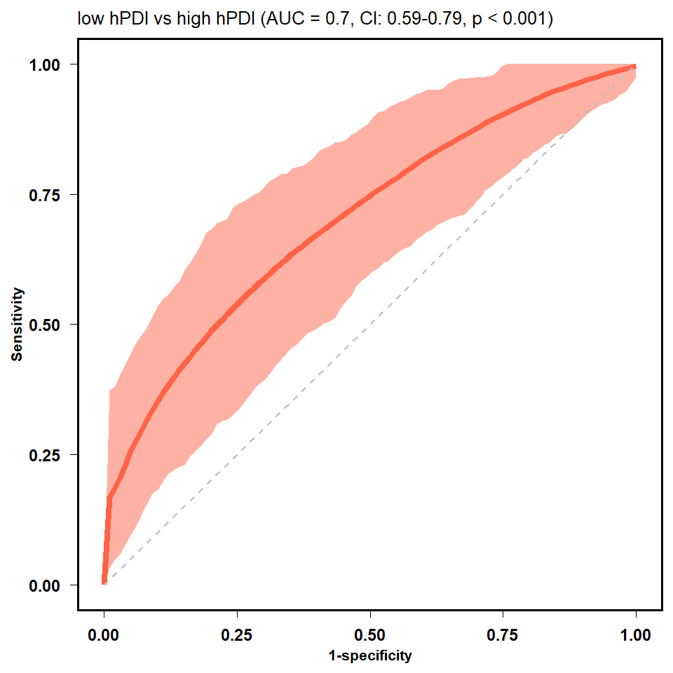

```r
adjusted_data <- adjust_for_covars(integrated_df, covars, sub_metadata_df)

model_name <- "adjusted_hpdi_model_vegan"

prepared_df <- model_preparation(adjusted_data,
                                 sub_metadata_df,
                                 predicting_col = "tertile_label")

rf_model <- make_rf_model(data=prepared_df,
                          outcome="Group",
                          N = 500,
                          file = model_name,
                          reuse=TRUE)

roc_c <- roc_curve(model_object = rf_model,
                   group = c("low hPDI","high hPDI"),CI = TRUE)

roc_c <- ggtheme(roc_c) +
  theme(legend.position="none",title = element_text(size=8))

roc_c
```

```r
# Find the "best" threshold using Youden's J Index
# This maximizes (Sensitivity + Specificity - 1)
roc_obj <- rf_model$rocobj
best_threshold_data <- coords(roc_obj, "best",
                              ret = "threshold",
                              best.method = "youden")
optimal_threshold <- best_threshold_data$threshold
optimal_threshold
```

```
[1] 0.4535167
```

```r
# saving the results
save_rf_details("../results/vegan/RF_models_performance.xlsx",model_name,rf_model)
```

```
[1] "Results saved to ../results/vegan/RF_models_performance.xlsx"
```

## 3.4 RF importance

### 3.4.1 Original model

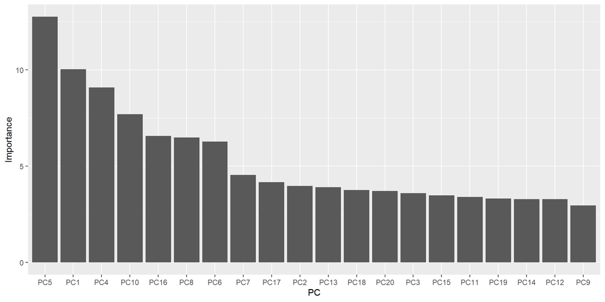

```r
load("../intermediate_files/models/hPDI_tertile_vegan/rf_model.RData")

var_imp <- as.data.frame(importance(rf_model$trained_model)) %>%
  rownames_to_column("PC") %>%
  `colnames<-`(c("PC","Importance"))

var_imp <- var_imp %>% dplyr::mutate(PC=factor(PC,levels = PC[order(var_imp$Importance,decreasing = TRUE)]))

ggplot(var_imp) +
  geom_col(aes(x=PC,y=Importance))
```

### 3.4.2 Adjusted model

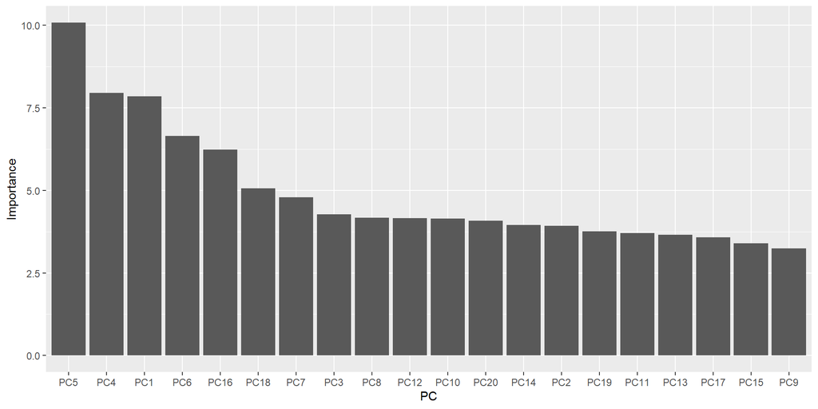

```r
load("../intermediate_files/models/adjusted_hpdi_model_vegan/rf_model.RData")

var_imp <- as.data.frame(importance(rf_model$trained_model)) %>%
  rownames_to_column("PC") %>%
  `colnames<-`(c("PC","Importance"))

var_imp <- var_imp %>% dplyr::mutate(PC=factor(PC,levels = PC[order(var_imp$Importance,decreasing = TRUE)]))

ggplot(var_imp) +
  geom_col(aes(x=PC,y=Importance))
```

### 3.4.3 Visualization

To explore the important PCs, their visualizations are shown below. We show **PC1** and **PC5**, which were selected by the original or the adjusted model. However, since the model’s performance was poor, these visualizations are rather redundant.

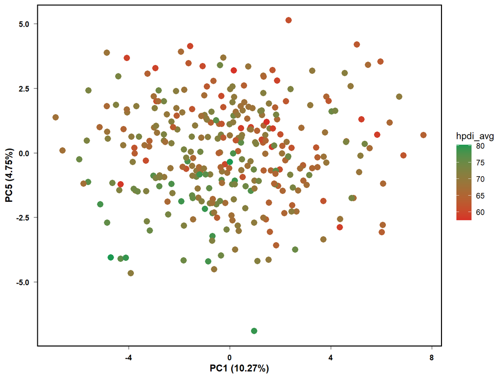

```r
spca_plot_df <- merge(
  spca_integrated_df %>% rownames_to_column("study_id"),
  metadata_df,by="study_id")

p <- pca_plot(spca_integrated_df,
              metadata_df,
              color_col = "hpdi_avg",
              perform_pca = FALSE,
              axis = c("PC1","PC5"))

p <- ggtheme(p)

p
```

```r
p_pca[[4]] <- p
```

# 4 Concatenated dataset

```r
concat_integrated_df <- cbind(lcms_df,nmr_df)
```

## 4.1 Visualization

### 4.1.1 Boxplots

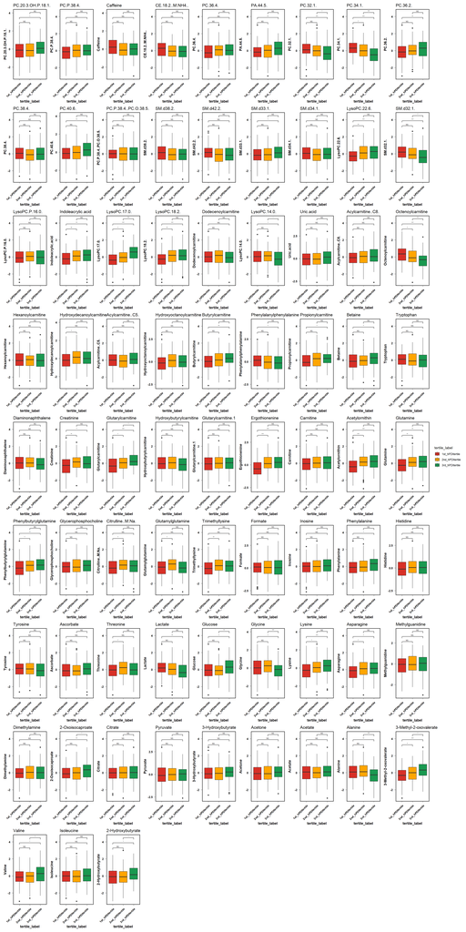

```r
concat_for_uni <- merge(concat_integrated_df %>% rownames_to_column("study_id"),
                      metadata_scaled_df,by="study_id",all = TRUE)

concat_for_uni <- concat_for_uni %>%
  mutate(
    tertile_cut = ntile(hpdi_avg, 3), # assign 1, 2, or 3 (tertile)
    tertile_label = case_when(                          # label tertiles
      tertile_cut == 1 ~ "1st_hPDItertile",
      tertile_cut == 2 ~ "2nd_hPDItertile",
      tertile_cut == 3 ~ "3rd_hPDItertile"
    )
  )

plot_list <- list()
for (col in colnames(concat_integrated_df)){
  p <- ggplot(concat_for_uni,
              aes(x = tertile_label,
                  y = !!sym(col),
                  fill=tertile_label)) +
    geom_boxplot() +
    ggtitle(col) +
    theme_minimal() +
    scale_fill_manual(values = c("#D73027","orange","#1A9850")) +
    geom_signif(comparisons =
                  combn(as.character(unique(concat_for_uni$tertile_label)),
                        m=2, simplify = FALSE),
                map_signif_level = TRUE, step_increase = 0.1,textsize = 2)

  p <- ggtheme(p) +
    theme(axis.text.x = element_text(angle=45,hjust = 1))
  plot_list[[length(plot_list) + 1]] <- p
}


a <- wrap_plots(plot_list,guides = "collect")

a
```

### 4.1.2 Heatmap

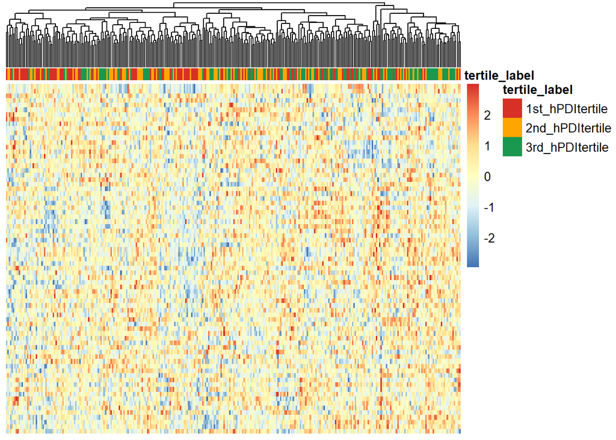

```r
VS_colors <- c("1st_hPDItertile"="#D73027",
               "2nd_hPDItertile"="orange",
               "3rd_hPDItertile"="#1A9850")

metadata_df <- metadata_df %>%
  mutate(
    tertile_cut = ntile(hpdi_avg, 3), # assign 1, 2, or 3 (tertile)
    tertile_label = case_when(                          # label tertiles
      tertile_cut == 1 ~ "1st_hPDItertile",
      tertile_cut == 2 ~ "2nd_hPDItertile",
      tertile_cut == 3 ~ "3rd_hPDItertile"
    )
  ) %>%
  dplyr::select(-tertile_cut)

p_df <- concat_integrated_df %>% t()

ann_df <- metadata_df %>% dplyr::select(study_id,tertile_label) %>%
  column_to_rownames("study_id")

ann_colors <- list(
  "tertile_label"=VS_colors
)
names(ann_colors[["tertile_label"]]) <- names(VS_colors)

p <- pheatmap(p_df,cluster_rows = FALSE,show_colnames = FALSE,
              show_rownames = FALSE,
              annotation_col = ann_df,
              annotation_colors = ann_colors,silent = TRUE)

p
```

## 4.2 Univariate analysis

We test the differences between diets and hPDI using a generalized linear model, while adjusting for covariates.

### 4.2.1 Continuous analysis

Metabolite ~ sex + bmi + age + eq_vegan_dur_total + Country*hPDI

```r
results_list <- lapply(colnames(concat_integrated_df),
                       function(x) fit_glm(x,concat_for_uni,
                                           tested_variable = "hpdi_avg"))
results_df <- do.call(rbind, results_list)

results_df$p_adjusted <- p.adjust(results_df$Pr...t..,method = "BH")
```

Significant results — **12 metabolites**:

```r
results_df %>%
  dplyr::filter(p_adjusted<0.05) %>%
  dplyr::filter(variable=="hpdi_avg")
```

```
           metabolite variable   Estimate Std..Error   t.value     Pr...t..
1            PC.34.1. hpdi_avg -0.4717187 0.10194040 -4.627397 5.462481e-06
2           SM.d38.2. hpdi_avg -0.3664556 0.10071778 -3.638440 3.215163e-04
3           SM.d42.2. hpdi_avg -0.3584519 0.11164211 -3.210723 1.463844e-03
4           SM.d34.1. hpdi_avg -0.2930141 0.10624328 -2.757955 6.163919e-03
5           SM.d32.1. hpdi_avg -0.2759094 0.10060100 -2.742611 6.452056e-03
6  Indoleacrylic.acid hpdi_avg  0.2960043 0.10587393  2.795819 5.502025e-03
7        LysoPC.17.0. hpdi_avg  0.3520656 0.10401152  3.384871 8.043373e-04
8   Octenoylcarnitine hpdi_avg -0.3869838 0.08685184 -4.455678 1.171962e-05
9      Ergothionenine hpdi_avg  0.3910311 0.10262863  3.810156 1.676683e-04
10     Acetylornithin hpdi_avg  0.3461605 0.10763620  3.216023 1.437945e-03
11          Glutamine hpdi_avg  0.3365305 0.10614915  3.170355 1.675733e-03
12  2-Hydroxybutyrate hpdi_avg  0.3020166 0.10817914  2.791819 5.568759e-03
     p_adjusted
1  0.0001170532
2  0.0037931693
3  0.0136020934
4  0.0417555818
5  0.0432701165
6  0.0382591158
7  0.0083619222
8  0.0002321812
9  0.0022285030
10 0.0134807389
11 0.0153001736
12 0.0384683977
```

```r
results_all <- (results_df %>%
  dplyr::filter(variable=="hpdi_avg"))

# save
write.table(results_all,"../results/vegan/Q3_hPDI//lm_continous_all.tsv",
            row.names = FALSE,
            quote=FALSE,
            sep="\t")
```

Interaction effect — **PC.32.1., SM.d34.1., Phenylbutyrylglutamine, Diaminonaphthalene**:

```r
df <- results_df %>%
  dplyr::filter(p_adjusted<0.05) %>%
  dplyr::filter(str_ends(variable, ":hpdi_avg"))

df
```

```
              metabolite           variable   Estimate Std..Error   t.value
1               PC.32.1. countryCH:hpdi_avg -0.5624098  0.1844316 -3.049422
2              SM.d34.1. countryDE:hpdi_avg  0.5011118  0.1487138  3.369639
3     Diaminonaphthalene countryDE:hpdi_avg -0.4440921  0.1510947 -2.939164
4 Phenylbutyrylglutamine countryDE:hpdi_avg -0.4301516  0.1477619 -2.911113
      Pr...t..  p_adjusted
1 0.0024918902 0.020282827
2 0.0008484435 0.008733977
3 0.0035398328 0.026739744
4 0.0038641962 0.028373469
```

```r
pc_to_be_removed <- df$metabolite
```

```r
concat_significant_df <- (results_df %>%
  dplyr::filter(p_adjusted<0.05) %>%
  dplyr::filter(variable=="hpdi_avg"))

concat_univariate_results <- results_df

concat_significant <- (results_df %>%
  dplyr::filter(p_adjusted<0.05) %>%
  dplyr::filter(variable=="hpdi_avg"))$metabolite

# save and show
write.table(concat_significant_df,"../results/vegan/Q3_hPDI//lm_continous.tsv",
            row.names = FALSE,
            quote=FALSE,
            sep="\t")

knitr::kable(concat_significant)
```

| x |
| --- |
| PC.34.1. |
| SM.d38.2. |
| SM.d42.2. |
| SM.d34.1. |
| SM.d32.1. |
| Indoleacrylic.acid |
| LysoPC.17.0. |
| Octenoylcarnitine |
| Ergothionenine |
| Acetylornithin |
| Glutamine |
| 2-Hydroxybutyrate |

**Volcano plot**

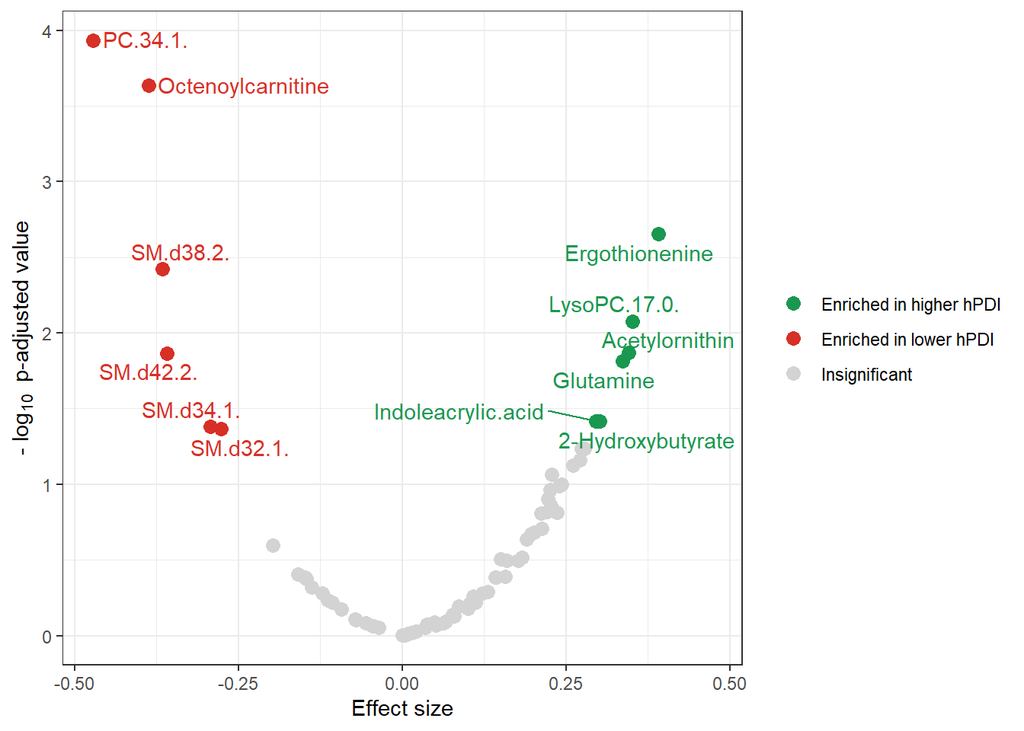

```r
vp <- volcano_plot(results_df,comparison = "hpdi_avg")
vp
```

**Correlation**

```r
sign <- (results_df %>%
  dplyr::filter(p_adjusted<0.05) %>%
  dplyr::filter(variable=="hpdi_avg"))$metabolite
```

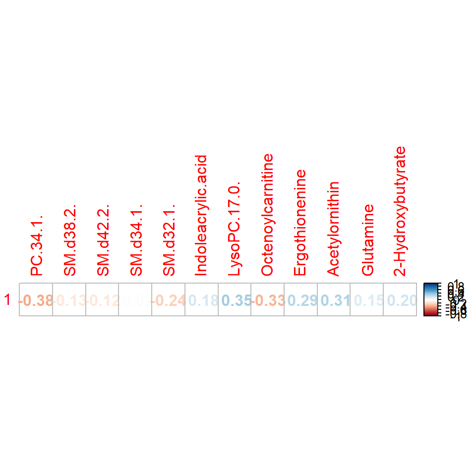

```r
df_for_plot <- concat_integrated_df %>% dplyr::select(sign)
corr_object <- cor(concat_for_uni$hpdi_avg,df_for_plot)
corrplot::corrplot(corr_object,method = "number")
```

**Vegan duration**

```r
results_df %>%
  dplyr::filter(p_adjusted<0.05) %>%
  dplyr::filter(variable=="vegan_duration")
```

```
          metabolite       variable  Estimate Std..Error  t.value    Pr...t..
1 Indoleacrylic.acid vegan_duration 0.1773656  0.0577357 3.072026 0.002315926
  p_adjusted
1 0.01945163
```

### 4.2.2 Pairwise analysis

Metab ~ sex + bmi + age + eq_vegan_dur_total + Country + tertile_label

**LM**

```r
results_list <- lapply(colnames(concat_integrated_df),
                       function(x) fit_netglm(x,concat_for_uni,
                                           tested_variable = "tertile_label"))
results_df <- do.call(rbind, results_list)

pdi_effects <- results_df %>%
  dplyr::mutate(p_adj = p.adjust(`p.value`, method = "BH"))

concat_significant_cat <-  pdi_effects %>%
  filter(p_adj < 0.05)
```

```r
results_list_pairwise <- lapply(colnames(concat_integrated_df),
                       function(x) fit_netglm_pairwise(x,concat_for_uni,
                                           tested_variable = "tertile_label"))
results_df_pairwise <- do.call(rbind, results_list_pairwise)

pdi_effects_pairwise <- results_df_pairwise %>%
  dplyr::mutate(p_adj = p.adjust(`p.value`, method = "BH"))

pdi_significant_pairwise <-  pdi_effects_pairwise %>%
  filter(p_adj < 0.05)
```

#### 4.2.2.1 Heatmap

```r
df2 <- pdi_effects_pairwise %>%
  mutate(
    contrast = gsub("_hPDItertile", "", contrast),
    signif = p_adj < 0.05
  )

df2$Significance <- ifelse(df2$p_adj<0.001,"***",
                                       ifelse(df2$p_adj<0.01,"**",
                                              ifelse(df2$p_adj<0.05,"*","")))
```

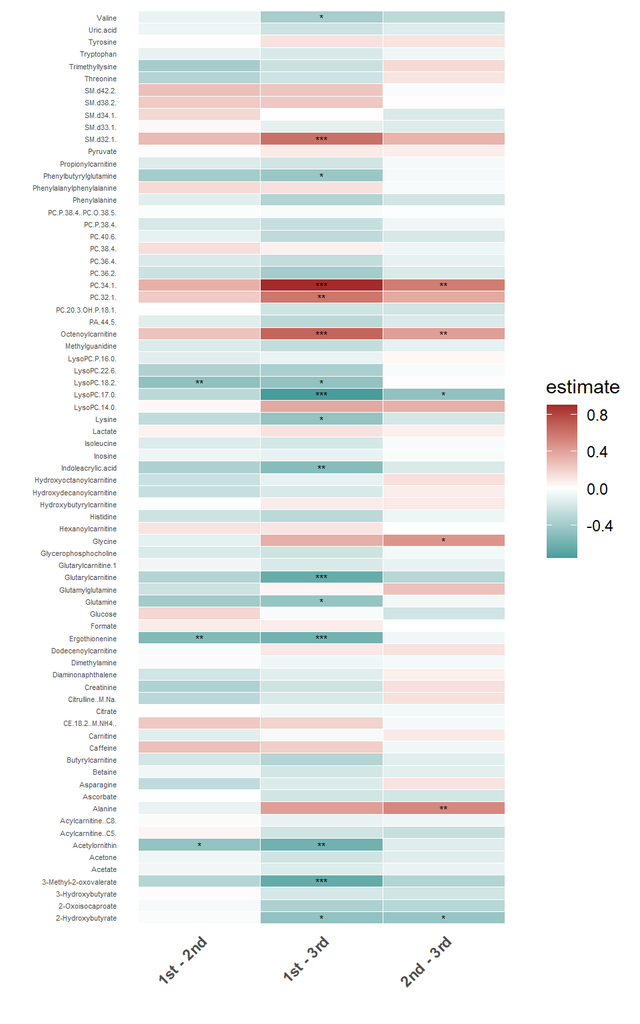

```r
p_pairwise_heatmap <- ggplot(df2, aes(x = contrast, y = Metabolite, fill = estimate)) +
  geom_tile(color = "white") +
  geom_text(aes(label = Significance,vjust=0.6), color = "black", size = 2) +
  scale_fill_gradient2(
    low = "darkcyan", mid = "white", high = "brown", midpoint = 0) +
  theme_minimal() +
  theme(axis.text.y = element_text(size=4),
        axis.text.x = element_text(angle = 45,face="bold",hjust = 1),
        panel.grid = element_blank()) +
  xlab("") + ylab("")

p_pairwise_heatmap
```

#### 4.2.2.2 Network construction

**Edge list**

```r
edges <- pdi_effects %>%
  filter(p_adj < 0.05) %>%
  #filter(abs(emmean)>0.3) %>%
  dplyr::select(from = tertile_label, to = metabolite,
         emmean = emmean) %>%
  dplyr::mutate(from=as.character(from),
         weight=abs(emmean))

edges$from <- as.character(edges$from)
edges$to   <- as.character(edges$to)
```

**Nodes table**

```r
tertiles <- as.character(unique(edges$from))
metabs <- as.character(unique(edges$to))

nodes <- data.frame(
  name = c(tertiles, metabs),
  type = c(rep(TRUE, length(tertiles)), rep(FALSE, length(metabs))) # TRUE = tertile, FALSE = metabolite
)
```

**Build igraph object**

```r
g <- graph_from_data_frame(d = edges, vertices = nodes, directed = FALSE)
```

**Visualize**

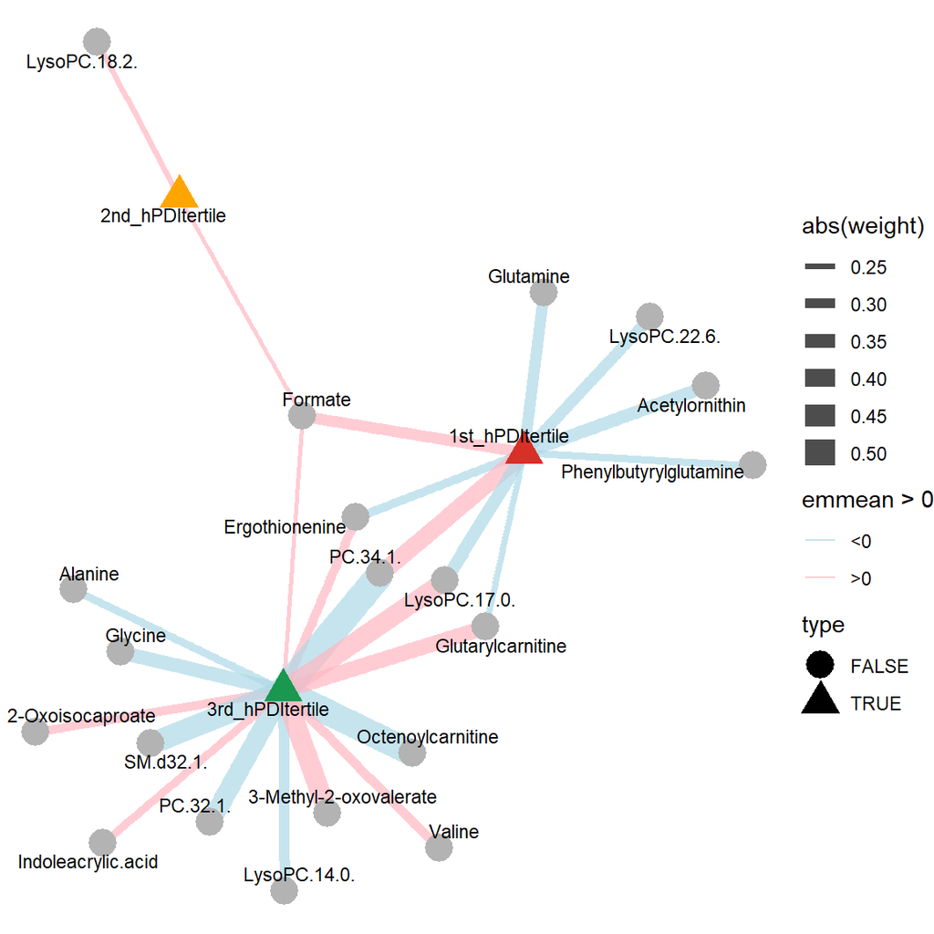

```r
VS_colors <- c("1st_hPDItertile"="#D73027",
               "2nd_hPDItertile"="orange",
               "3rd_hPDItertile"="#1A9850")

# Assign colors to nodes: countries get their color, metabolites gray
V(g)$color <- ifelse(V(g)$type,
                     VS_colors[V(g)$name],
                     "gray70")

set.seed(123)
ggraph(g, layout = "fr") +
  geom_edge_link(aes(width = abs(weight), color = emmean > 0), alpha = 0.7) +
  scale_edge_color_manual(values = c("lightblue", "lightpink"), labels = c("<0", ">0")) +
  geom_node_point(aes(shape=type,color = name), size = 6) +
  scale_color_manual(values = setNames(V(g)$color, V(g)$name)) +  # node colors
  geom_node_text(aes(label = name), repel = TRUE, size = 3) +
  theme_void() +
  guides(color = "none")
```

#### 4.2.2.3 Top-group assignment

**All together**

```r
PDI_colors <- c("1st_hPDItertile"="#D73027",
               "2nd_hPDItertile"="orange",
               "3rd_hPDItertile"="#1A9850",
               "other"="gray70")

# Assign colors to nodes: countries get their color, metabolites gray
V(g)$color <- ifelse(V(g)$type,
                     PDI_colors[V(g)$name],
                     "gray70")

top_group <- edges %>%
  dplyr::group_by(to) %>%
  slice_max(order_by = abs(weight), n = 1, with_ties = FALSE) %>%
  dplyr::select(from,to, weight) %>%
  ungroup()

top_group
```

```
# A tibble: 20 × 3
   from            to                     weight
   <chr>           <chr>                   <dbl>
 1 3rd_hPDItertile 2-Oxoisocaproate        0.291
 2 3rd_hPDItertile 3-Methyl-2-oxovalerate  0.435
 3 1st_hPDItertile Acetylornithin          0.338
 4 3rd_hPDItertile Alanine                 0.282
 5 3rd_hPDItertile Ergothionenine          0.304
 6 1st_hPDItertile Formate                 0.319
 7 1st_hPDItertile Glutamine               0.325
 8 3rd_hPDItertile Glutarylcarnitine       0.375
 9 3rd_hPDItertile Glycine                 0.356
10 3rd_hPDItertile Indoleacrylic.acid      0.288
11 3rd_hPDItertile LysoPC.14.0.            0.316
12 3rd_hPDItertile LysoPC.17.0.            0.423
13 2nd_hPDItertile LysoPC.18.2.            0.255
14 1st_hPDItertile LysoPC.22.6.            0.324
15 3rd_hPDItertile Octenoylcarnitine       0.500
16 3rd_hPDItertile PC.32.1.                0.416
17 3rd_hPDItertile PC.34.1.                0.516
18 1st_hPDItertile Phenylbutyrylglutamine  0.276
19 3rd_hPDItertile SM.d32.1.               0.452
20 3rd_hPDItertile Valine                  0.300
```

```r
top_group_viz <- rbind(top_group,
                       data.frame(
                         from=unique(edges$from),
                         to=unique(edges$from),
                         weight=NA))

membership_df <- data.frame(
  vertex = top_group_viz$to,
  cluster = top_group_viz$from)

membership_df <- membership_df %>% arrange(match(vertex,names(V(g))))
```

```r
pdi_clusters <- (membership_df %>%
  group_by(cluster) %>%
  summarise(metabolites = paste(unique(vertex), collapse = ", ")))[1:3,]

(membership_df %>%
  group_by(cluster) %>%
  summarise(Number_of_metabolites = length(unique(vertex))-1))[1:3,]
```

```
# A tibble: 3 × 2
  cluster         Number_of_metabolites
  <chr>                           <dbl>
1 1st_hPDItertile                     5
2 2nd_hPDItertile                     1
3 3rd_hPDItertile                    14
```

```r
pdi_clusters
```

```
# A tibble: 3 × 2
  cluster         metabolites
  <chr>           <chr>
1 1st_hPDItertile 1st_hPDItertile, LysoPC.22.6., Acetylornithin, Glutamine, Phe…
2 2nd_hPDItertile 2nd_hPDItertile, LysoPC.18.2.
3 3rd_hPDItertile 3rd_hPDItertile, PC.32.1., PC.34.1., SM.d32.1., Indoleacrylic…
```

```r
V(g)$fill <- VS_colors[membership_df$cluster]
V(g)$color <- VS_colors[membership_df$cluster]
```

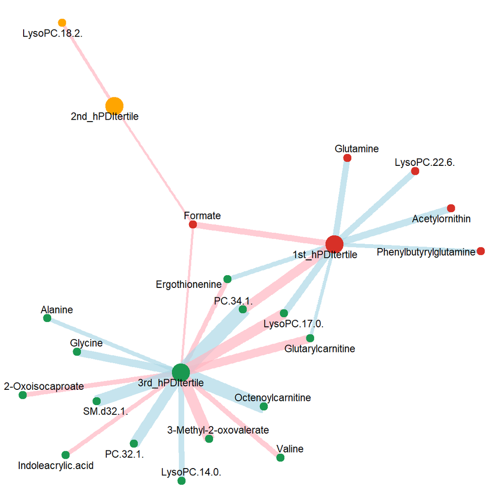

```r
set.seed(123)
p_all <- ggraph(g, layout = "fr") +
  geom_edge_link(aes(width = abs(weight), color = emmean > 0), alpha = 0.7) +
  scale_edge_color_manual(values = c("lightblue","lightpink"),labels = c("<0", ">0")) +
  geom_node_point(aes(size=type,color = name,fill=name),shape=21,stroke=1.2) +
  scale_color_manual(values = setNames(V(g)$color, V(g)$name))   + # node colors
  scale_fill_manual(values = setNames(V(g)$fill, V(g)$name)) +  # node fill
  geom_node_text(aes(label = name), repel = TRUE, size = 3) +
  theme_void() +
  theme(legend.position = "none")


p_all
```

```r
list_core <- list()

list_core[["concat_univariate"]] <- unique(concat_significant)
```

# 5 Final significant metabolites

```r
final_significance <- list_core[["concat_univariate"]]
final_significance
```

```
 [1] "PC.34.1."           "SM.d38.2."          "SM.d42.2."
 [4] "SM.d34.1."          "SM.d32.1."          "Indoleacrylic.acid"
 [7] "LysoPC.17.0."       "Octenoylcarnitine"  "Ergothionenine"
[10] "Acetylornithin"     "Glutamine"          "2-Hydroxybutyrate"
```

# 6 Metabolite-based hPDI

## 6.1 Continuous univariate test

To build a vegan index from the concatenated dataset, we use linear regression to obtain coefficients for the significant variables identified across the analysis:

```r
final_significance
```

```
 [1] "PC.34.1."           "SM.d38.2."          "SM.d42.2."
 [4] "SM.d34.1."          "SM.d32.1."          "Indoleacrylic.acid"
 [7] "LysoPC.17.0."       "Octenoylcarnitine"  "Ergothionenine"
[10] "Acetylornithin"     "Glutamine"          "2-Hydroxybutyrate"
```

```r
sign <- final_significance
```

```r
# define the variables
plot_list <- list()
rhos <- rep(NA,5)
ps <- rep(NA,5)

# split the datasets for cross-validation
concat_for_index <- concat_for_uni[sample(rownames(concat_for_uni)),]
set.seed(123)
cv_splits <- cv_folds(concat_for_index,folds = 5)

final_df_veganindex <- data.frame()

# cross validation loop
vars_selection <- list()
for (i in 1:length(cv_splits)){
  unisub_df <- concat_for_uni[cv_splits[[i]]$train,]
  results_list <- lapply(colnames(concat_integrated_df),
                       function(x) fit_glm(x,unisub_df,
                                           tested_variable = "hpdi_avg"))
  results_df <- do.call(rbind, results_list)

  results_df$p_adjusted <- p.adjust(results_df$Pr...t..,method = "BH")

  vars <- results_df$metabolite[results_df$p_adjusted<0.05 & results_df$variable=="hpdi_avg"]
  vars_selection[[i]] <- vars

  # Wrap all variable names in backticks
  vars_safe <- paste0("`", vars, "`")

  fml <- as.formula(paste("hpdi_avg ~", paste(vars_safe, collapse = " + ")))

  # fit the model
  model <- lm(fml, unisub_df)

  # predict the result on validation dataset
  VG_index <- stats::predict(model,concat_for_uni[cv_splits[[i]]$val,])

  # store the predicted index
  sub_df <- concat_for_uni[cv_splits[[i]]$val,]
  sub_df$VGindex <- VG_index
  final_df_veganindex <- rbind(final_df_veganindex,sub_df)

  # calculate correlation
  cor_test <- cor.test(sub_df$VGindex,
               sub_df$hpdi_avg,
               method = "spearman")
  cor_val <- cor_test$estimate
  if (cor_test$p.value >0.05) cor_val = 0

  # plot the result
  p <- ggplot(sub_df,
              aes_string(x = "VGindex", y = "hpdi_avg"),
              color="blue") +
       geom_point() +
    geom_smooth(method = "lm") +
    theme_minimal() +
    ggtitle(paste("Rho =",round(cor_val,2)))

  plot_list[[i]] <- p
  rhos[i] <- round(cor_val,2)
  ps[i] <- cor_test$p.value
}
```

```r
mean(rhos)
```

```
[1] 0.49
```

```r
# Fisher's method to combine p-values
library(metap)
combined_p <- sumlog(ps)$p
combined_p
```

```
[1] 1.285545e-18
```

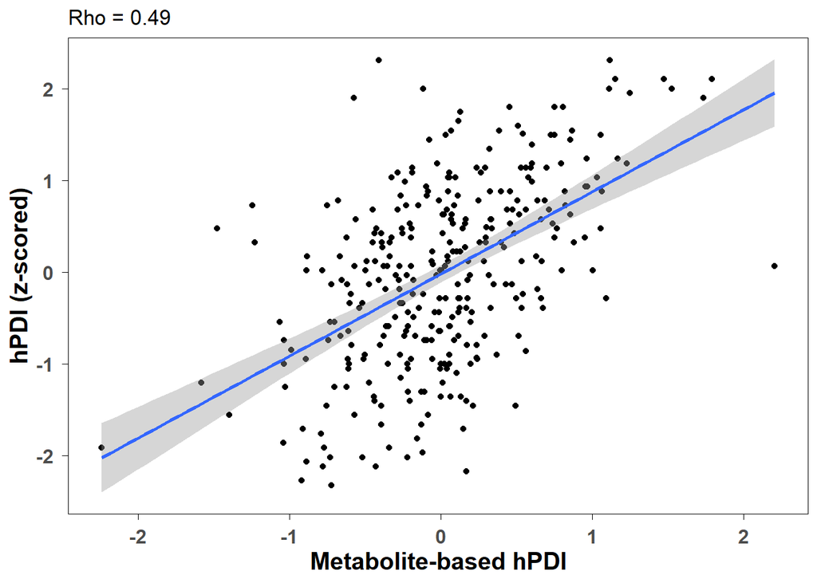

```r
# calculate correlation
  cor_test <- cor.test(final_df_veganindex$VGindex,
               final_df_veganindex$hpdi_avg,
               method = "spearman")
  cor_val <- cor_test$estimate
  if (cor_test$p.value >0.05) cor_val = 0

  # plot the result
  p <- ggplot(final_df_veganindex,
              aes_string(x = "VGindex", y = "hpdi_avg"),
              color="blue") +
       geom_point() +
    geom_smooth(method = "lm") +
    theme_minimal() +
      theme(panel.border =
              element_rect(color = "black", fill = NA, size = 0),
            panel.grid = element_blank(),
            axis.ticks.x =
              element_line(size=0.3,color = "black"),
            axis.ticks.y =
              element_line(size=0.3,color="black"),
            axis.ticks.length = unit(4,"pt"),
            axis.text=element_text(face="bold",size=12),
            axis.title = element_text(face="bold",size=15)) +
    ggtitle(paste("Rho =",round(cor_val,2))) +
    xlab("Metabolite-based hPDI") +
    ylab("hPDI (z-scored)")
p
```

```r
f <- p + ggtitle("")
save(f,file="../results/vegan/figures/F5c_hPMI.RData")
```

# 7 Plot for publication

## 7.1 PCA

[figure not shown]

```r
p1 <- p_pca[[1]]
country_leg <- ggpubr::get_legend(p1)
p1 <- p1 + theme(legend.position = "none")

p2 <- p_pca[[4]]
p2 <- p2 + theme(legend.position = "none")

p3 <- p_pca[[2]] +
  geom_text(aes(x=0.25,y=1),label=paste0("R²=",round(p_pca[[3]]$R2[6],3),"\n p=0.59"),size=2)

factor_leg <- ggpubr::get_legend(p3)
p3 <- p3 + theme(legend.position = "none")

legends <- ggarrange(country_leg, factor_leg, nrow = 2, align = "hv")

layout <- "
AABBDD
AABBDD
AABBDD
CCCCDD
"

# Now plot!
p1 + p2 + p3 + legends +
plot_layout(design = layout, heights = c(2,2,2,1),widths = c(1,1,1,1,1,1))
```

## 7.2 Heatmap

### 7.2.1 Pairwise

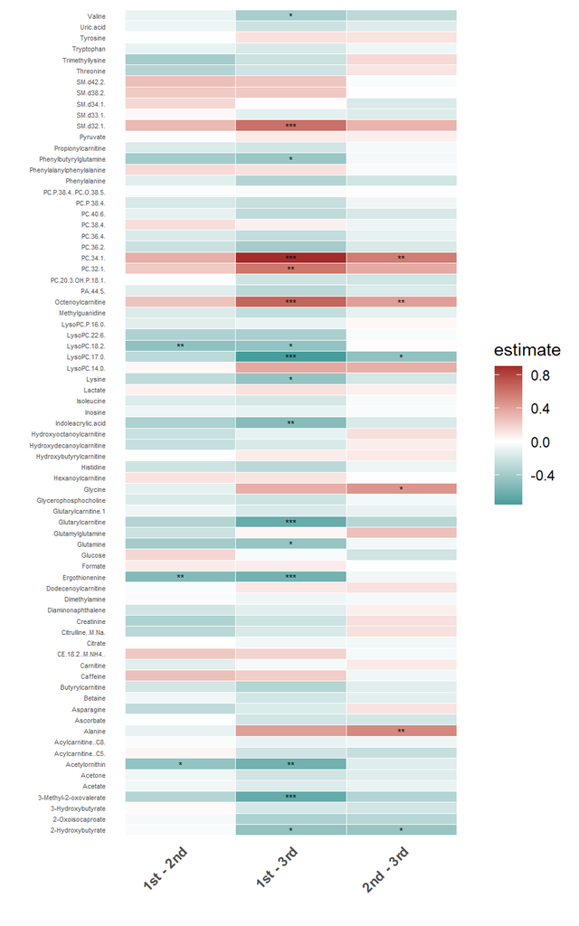

```r
p_pairwise_heatmap
```

## 7.3 Forest plot

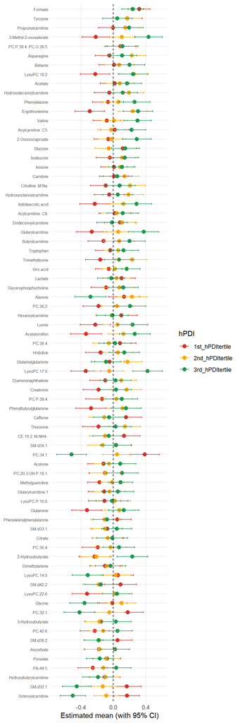

```r
# Define custom colours
PDI_colors <- c("1st_hPDItertile"="#D73027",
               "2nd_hPDItertile"="orange",
               "3rd_hPDItertile"="#1A9850")

# Optional: order metabolites by mean effect size
forest_df <- pdi_effects %>%
  group_by(metabolite) %>%
  mutate(mean_eff = mean(emmean)) %>%
  ungroup()

forest_df$metabolite <- factor(
  forest_df$metabolite,
  levels = forest_df %>%
    arrange(mean_eff) %>%
    pull(metabolite) %>%
    unique()
)

# Forest plot WITHOUT ANY TEXT LABELS
p_forest <- ggplot(forest_df,
                   aes(x = emmean,
                       y = metabolite,
                       color = tertile_label)) +

  geom_point(size = 2.5) +
  geom_errorbarh(aes(xmin = lower.CL, xmax = upper.CL), height = 0.2) +
  geom_vline(xintercept = 0, linetype = "dashed") +

  scale_color_manual(values = VS_colors) +

  theme_minimal() +
  theme(axis.title.y = element_blank(),
        axis.text.y = element_text(size = 6),
        panel.grid.minor = element_blank()) +

  labs(
    x = "Estimated mean (with 95% CI)",
    color = "hPDI"
  )

p_forest
```

## 7.4 Network

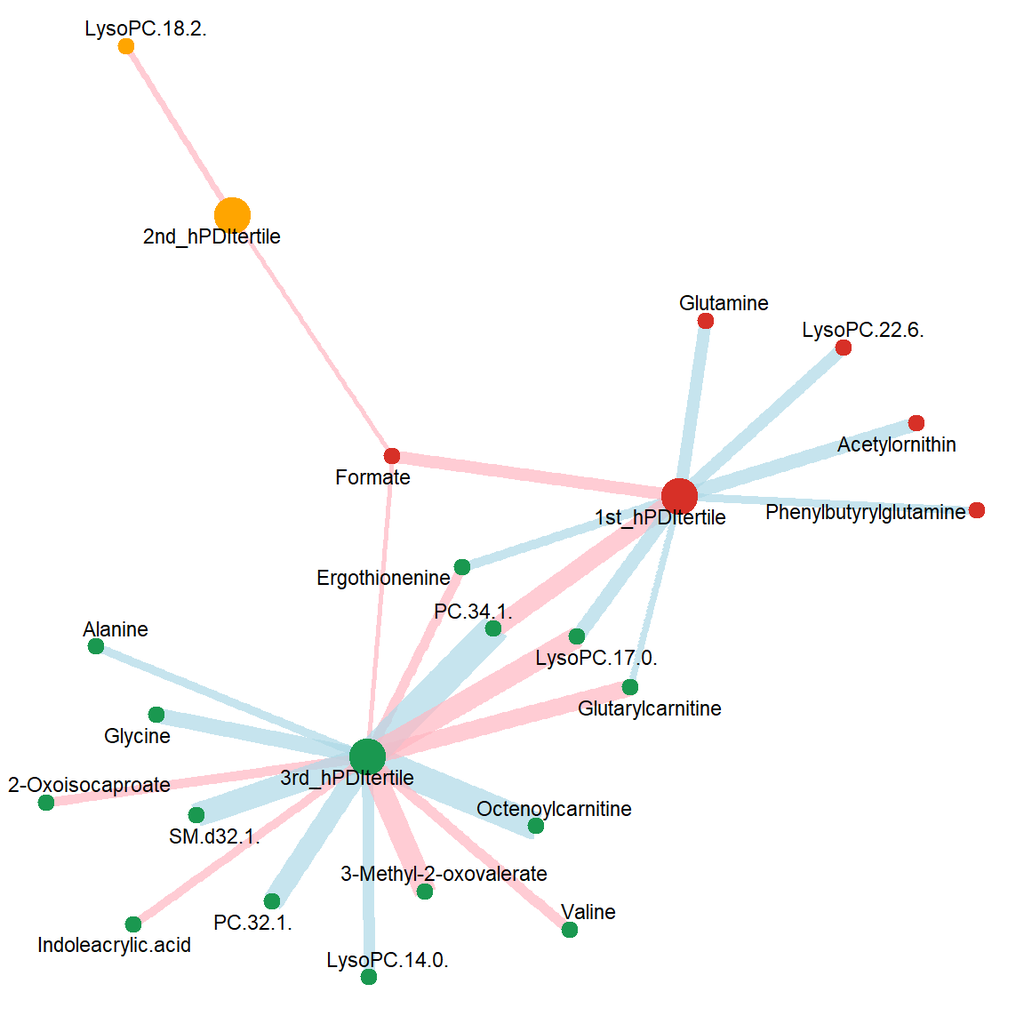

```r
p_all
```